# Proyecto entrega 3

- Antonio Lomelí Ureña - Carolina Martínez - Enrique Tonatiuh Pérez Cortés - Eddie Aguilar

2024-03-12

## Introducción

Sin duda, el precio y el rendimiento de un activo al invertir resultan fundamentales para decidir si una inversión será buena o mala. Pero ¿cómo saber qué rendimiento se tendrá en el plazo deseado o qué precio tendrá el activo al final del tiempo de la inversión? Saberlo con exactitud es completamente imposible, ya que estos dependen de muchos factores que no pueden ser controlados; sin embargo, es posible realizar estimaciones tanto del precio como del rendimiento de una acción, basándose en los datos históricos de esta misma.

Para esta parte del proyecto, se mostrarán diversas estimaciones tanto del precio como del rendimiento de la acción de la empresa FEMSA dentro de la Bolsa Mexicana de Valores para distintas temporalidades. Para lograrlo, se calculará el rendimiento promedio del activo, así como la volatilidad de este, además de utilizar distintos métodos, dependiendo de la temporalidad. Para asegurarse de que las estimaciones serán útiles y aportarán información valiosa sobre la inversión en este activo, se trabajará con intervalos de confianza en busca de que estas estimaciones tengan el mínimo error posible.

Se expondrá cada resultado obtenido de manera ordenada y al final se hará un breve análisis sobre el teorema utilizado en este proyecto.

## Estimación del rendimiento

### Anual

```
## [1] 0.1272878
```

El rendimiento anual calculado es del 12.73%

### Diario

```
## [1] 0.0005051102
```

El rendimiento diario calculado es del .05%

## Estimación de la volatilidad

### Anual

```
## [1] 0.272432
```

La volatilidad anual calculada es del 27.24%

### Diaria

```
## [1] 0.01716161
```

La volatilidad diaria calculada es del 1.72%

## Datos por año

A continuación, se presenta una tabla que recopila los datos previamente calculados de manera ordenada.

```
## # A tibble: 25 × 5
##     year     rend_d  vol_d   rend_a vol_a
##    <dbl>      <dbl>  <dbl>    <dbl> <dbl>
##  1  2000 -0.00136   0.0291 -0.344   0.462
##  2  2001  0.000357  0.0220  0.0901  0.348
##  3  2002  0.000831  0.0191  0.210   0.303
##  4  2003  0.000381  0.0121  0.0961  0.191
##  5  2004  0.00135   0.0148  0.341   0.234
##  6  2005  0.00131   0.0119  0.330   0.189
##  7  2006  0.00190   0.0159  0.480   0.253
##  8  2007  0.0000405 0.0190  0.0102  0.301
##  9  2008  0.0000109 0.0299  0.00275 0.475
## 10  2009  0.00169   0.0233  0.425   0.370
## # ℹ 15 more rows
```

## Prueba de normalidad

### Rendimiento

```r
jarque.test(as.numeric(rend))
```

```
##
##  Jarque-Bera Normality Test
##
## data:  as.numeric(rend)
## JB = 9966, p-value < 2.2e-16
## alternative hypothesis: greater
```

### Precio

```r
jarque.test(as.numeric(precio))
```

```
##
##  Jarque-Bera Normality Test
##
## data:  as.numeric(precio)
## JB = 569.79, p-value < 2.2e-16
## alternative hypothesis: greater
```

### Logaritmo del precio

```r
jarque.test(as.numeric(log(precio)))
```

```
##
##  Jarque-Bera Normality Test
##
## data:  as.numeric(log(precio))
## JB = 654.42, p-value < 2.2e-16
## alternative hypothesis: greater
```

Se aplica la prueba de Jarque-Bera a las distribuciones del rendimiento, precio y el logaritmo del precio.

La hipótesis nula ($H_0$) de la prueba es que los datos se distribuyen normalmente.También es importante recordar que la prueba de Jarque-Bera utiliza la `curtosis` y `asimetría` de la distribución para determinar si es normal o no.

Como el `p-value` de todas las pruebas fue menor a 5% (el nivel de significancia escogido), **se rechaza la hipótesis nula**, los datos no siguen una distribución normal.

Es esperable encontrar estos resultados, sobretodo considerando que el test utiliza la curtosis y asimetría de la distribución.

La variable que, en teoría, más se asemeja a una distribución normal es la del rendimiento. Los hechos estilizados suponen que el rendimiento tiene una forma aproximadamente acampanada, pero son leptocúrticas y tienen colas largas y pesadas, lo que ocasiona una “desviación” considerable de la curva normal, como se observa en la siguiente gráfica:

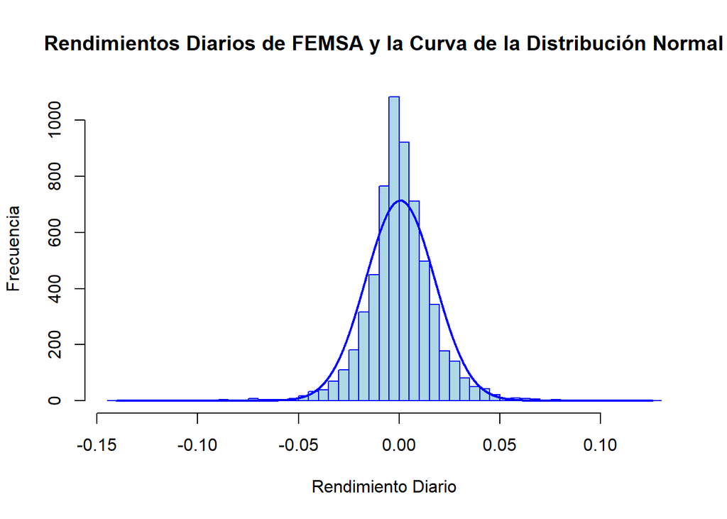

```r
x <- coredata(rend)
len <- length(rend)

plotNormalHistogram( x, prob = FALSE,
                    main = "Rendimientos Diarios de FEMSA y la Curva de la Distribución Normal",
                    xlab = "Rendimiento Diario",
                    ylab = "Frecuencia",
                    length = len,
                    breaks = 80,
                    col = "lightblue",
                    border = "blue")
```

Hay muchísimos valores muy cercanos a la media de los rendimientos, la frecuencia se sale de la curva normal, ese es el efecto de la curtosis. Las colas tienen frecuencias importantes, algo que no contempla la forma normal, donde la probabilidad de ocurrencia en eventos extremos es prácticamente inexistente.

## Ecuación ds

$$ds = s\mu dt+s\sigma dW$$

### Estimado del precio en 10 días (95% de confianza)

```r
Ren_d_2023 <- as.numeric(tabla_est[24,2])
Vol_d_2023<- as.numeric(tabla_est[24,3])
s0 <-as.numeric(xts::last(precio))
dt <- 10
epsilon <- rnorm(n=500000,mean=0,sd=1)
ds <- s0*Ren_d_2023*dt + s0*Vol_d_2023*epsilon*sqrt(dt)
```

*Cambio esperado*

```r
mean(ds)
```

```
## [1] 3.224652
```

*Precio esperado para 10 días*

```r
Precio_Esperado_10d <- s0+mean(ds)
Precio_Esperado_10d
```

```
## [1] 208.2346
```

*Intervalo de confianza a 95%*

```r
z <- qnorm((1-.95)/2)
cat("(",Precio_Esperado_10d+z*sd(ds),",",Precio_Esperado_10d-z*sd(ds),")")
```

```
## ( 191.4718 , 224.9975 )
```

### Estimado del precio en 20 días (95% de confianza)

```r
dt <- 20
ds <- s0*Ren_d_2023*dt + s0*Vol_d_2023*epsilon*sqrt(dt)
```

*Cambio esperado*

```r
mean(ds)
```

```
## [1] 6.451905
```

*Precio esperado para 20 días*

```r
Precio_Esperado_20d <- s0+mean(ds)
Precio_Esperado_20d
```

```
## [1] 211.4619
```

*Intervalo de confianza a 95%*

```r
z <- qnorm((1-.95)/2)
cat("(",Precio_Esperado_20d+z*sd(ds),",",Precio_Esperado_20d-z*sd(ds),")")
```

```
## ( 187.7557 , 235.1681 )
```

### Estimado del precio en 40 días (95% de confianza)

```r
dt <- 40
ds <- s0*Ren_d_2023*dt + s0*Vol_d_2023*epsilon*sqrt(dt)
```

*Cambio esperado*

```r
mean(ds)
```

```
## [1] 12.90749
```

*Precio esperado para 40 días*

```r
Precio_Esperado_40d <- s0+mean(ds)
Precio_Esperado_40d
```

```
## [1] 217.9175
```

*Intervalo de confianza a 95%*

```r
z <- qnorm((1-.95)/2)
cat("(",Precio_Esperado_40d+z*sd(ds),",",Precio_Esperado_40d-z*sd(ds),")")
```

```
## ( 184.3918 , 251.4431 )
```

## Ecuación ln(St)

$$ln(S_t) =
ln(S_0)+(\mu-\frac{1}{2}\sigma^2)dt+\sigma dW$$

### Estimado del precio en 3 meses (95% de confianza)

```r
dt <- 252/4 # Para obtener el valor de un trimestre en días
ln_St <- log(s0)+(Ren_d_2023-0.5*Vol_d_2023^2)*dt+Vol_d_2023*epsilon*sqrt(dt)
```

*Precio esperado en 3 meses*

```r
precio_3m <- exp(mean(ln_St))
precio_3m
```

```
## [1] 225.1447
```

*Intervalo de confianza a 95%*

```r
intervalo1 <- exp(mean(ln_St)+z*sd(ln_St))
intervalo2 <- exp(mean(ln_St)-z*sd(ln_St))
cat("(",intervalo1,",",intervalo2,")")
```

```
## ( 183.3712 , 276.4346 )
```

### Estimado del precio en 6 meses (95% de confianza)

```r
dt <- 252/2 # Para obtener el valor de medio año en días
ln_St <- log(s0)+(Ren_d_2023-0.5*Vol_d_2023^2)*dt+Vol_d_2023*epsilon*sqrt(dt)
```

*Precio esperado en 6 meses*

```r
precio_6m <- exp(mean(ln_St))
precio_6m
```

```
## [1] 247.2648
```

*Intervalo de confianza a 95%*

```r
intervalo1 <- exp(mean(ln_St)+z*sd(ln_St))
intervalo2 <- exp(mean(ln_St)-z*sd(ln_St))
cat("(",intervalo1,",",intervalo2,")")
```

```
## ( 184.9748 , 330.5308 )
```

### Estimado del precio en 9 meses (95% de confianza)

```r
dt <- 252*0.75 # Para obtener el valor de 9 meses en días
ln_St <- log(s0)+(Ren_d_2023-0.5*Vol_d_2023^2)*dt+Vol_d_2023*epsilon*sqrt(dt)
```

*Precio esperado en 9 meses*

```r
precio_9m <- exp(mean(ln_St))
precio_9m
```

```
## [1] 271.5595
```

*Intervalo de confianza a 95%*

```r
intervalo1 <- exp(mean(ln_St)+z*sd(ln_St))
intervalo2 <- exp(mean(ln_St)-z*sd(ln_St))
cat("(",intervalo1,",",intervalo2,")")
```

```
## ( 190.3208 , 387.4751 )
```

### Estimado del precio en 12 meses (95% de confianza)

```r
dt <- 252 # Valor de un año en días
ln_St <- log(s0)+(Ren_d_2023-0.5*Vol_d_2023^2)*dt+Vol_d_2023*epsilon*sqrt(dt)
```

*Precio esperado en 12 meses*

```r
precio_12m <- exp(mean(ln_St))
precio_12m
```

```
## [1] 298.2421
```

*Intervalo de confianza a 95%*

```r
intervalo1 <- exp(mean(ln_St)+z*sd(ln_St))
intervalo2 <- exp(mean(ln_St)-z*sd(ln_St))
cat("(",intervalo1,",",intervalo2,")")
```

```
## ( 197.8371 , 449.6041 )
```

## Ecuación St

Para hacer una comprobación de los valores que se obtuvieron con ln(St), se va a simular el precio utilizando la ecuación:

$$S_t=S_0e^{(\mu-0.5\sigma^2)dt+\sigma
dW}$$

### Estimado del precio en 3 meses

```r
dt <- 252/4 # Para obtener el valor de un trimestre en días
St <- s0*exp((Ren_d_2023-0.5*Vol_d_2023^2)*dt+Vol_d_2023*epsilon*sqrt(dt))
mean(St)
```

```
## [1] 226.3824
```

### Estimado del precio en 6 meses

```r
dt <- 252/2 # Para obtener el valor de medio año en días
St <- s0*exp((Ren_d_2023-0.5*Vol_d_2023^2)*dt+Vol_d_2023*epsilon*sqrt(dt))
mean(St)
```

```
## [1] 249.9908
```

### Estimado del precio en 9 meses

```r
dt <- 252*0.75 # Para obtener el valor de 9 meses en días
St <- s0*exp((Ren_d_2023-0.5*Vol_d_2023^2)*dt+Vol_d_2023*epsilon*sqrt(dt))
mean(St)
```

```
## [1] 276.0627
```

### Estimado del precio en 12 meses

```r
dt <- 252 # Valor de un año en días
St <- s0*exp((Ren_d_2023-0.5*Vol_d_2023^2)*dt+Vol_d_2023*epsilon*sqrt(dt))
mean(St)
```

```
## [1] 304.8546
```

Se puede ver que los valores obtenidos con la ecuación de $S_t$ son muy parecidos a los que se obtuvieron con la ecuación de $ln(St)$

## Discusión sobre el teorema

Retomando los rendimientos diarios graficados en comparación a la distribución normal, podemos ver como este tipo de modelos no estiman completamente bien los rendimientos y precios del activo. Esto debido a que los datos nos dejan ver que no están en realidad distribuidos normalmente y puede llegar a tener valores externos, cosa que no sucede en una distribución normal. Sin embargo, para el modelo teórico suponemos eso para llevarlo a cabo. Podemos ver en la gráfica como hay varios datos que se agrupan bastante en la media de la distribución normal siendo incluso más altos, y de la misma forma no se distribuye a lo largo de la gráfica perfectamente.